# Machine Learning Workflows & Evaluation

Unit 3 Handout

Dr. Ankit Deshmukh

2026-09-11

```r
# ggplot2 is used for all plots. If missing, this line installs it once.
if (!requireNamespace("ggplot2", quietly = TRUE)) {
  install.packages("ggplot2", repos = "https://cloud.r-project.org")
}
library(ggplot2)
```

# What You Will Learn in Unit 3

By the end of this handout, you will be able to:

1. **Describe the full Machine Learning (ML) workflow** — from question to deployed model. *(CO4)*
2. **Prepare civil engineering data**: clean it, scale it, and encode categories. *(CO3)*
3. **Engineer smart features** like rainfall intensity, runoff coefficient, and NDVI anomalies. *(CO3)*
4. **Train and validate models** using train/test splits. *(CO4)*
5. **Evaluate regression models** (MAE, RMSE, R²) and **classification models** (Accuracy, Precision, Recall, F1, ROC). *(CO5)*
6. **Diagnose overfitting vs. underfitting** and use **cross-validation** to pick reliable models. *(CO5)*

️**Civil connection:** Every idea in this unit is shown with a civil example — concrete strength, floods, rainfall, runoff, vegetation health, and groundwater. Same tools, real site problems.

**How to use this handout:** Read a topic, then run its code chunk in RStudio (or knit the whole file). Change the numbers and see what happens — that is how engineers learn machines!

# The Machine Learning Workflow

### What is it?

Machine Learning is teaching a computer to find patterns in data, so it can make predictions on **new, unseen data**. The workflow is the step-by-step recipe we always follow:

| Step | What happens | Civil engineering example |
| --- | --- | --- |
| **1. Ask a question** | Define the prediction goal | “What will be the 28-day strength of this concrete mix?” |
| **2. Collect data** | Gather measurements | Cube-crushing test records: cement, water, age, strength |
| **3. Prepare data** | Clean, scale, encode, engineer features | Fix missing sensor readings, convert soil types to numbers |
| **4. Split data** | Separate into training and testing sets | Mock exam vs. final exam |
| **5. Train the model** | Let the algorithm learn patterns | Model learns “more cement + proper curing → stronger” |
| **6. Evaluate** | Check accuracy on unseen test data | RMSE of strength predictions |
| **7. Use & improve** | Deploy, monitor, retrain | Live strength predictor on the batching plant |

**Key idea:** The model is like a student. You teach it with the **training set** (mock exams) and judge it with the **test set** (final exam it has never seen). Judging a student on questions they already memorised proves nothing.

️**Never evaluate on training data.** A model that is graded on data it has already seen will always look artificially good. This is called **data leakage**, and it is the #1 beginner mistake.

# Data Preparation — Cleaning the Site Before Building

️**Civil connection:** You never build on an uncleared site. You remove debris, level the ground, and set out the grid. Data preparation is exactly this — and it usually takes **60–80% of a data scientist’s time**.

## 2.1 Data Cleaning (missing values, duplicates, impossible values)

**Why?** Real sensor logs and lab registers always have gaps (sensor failure), repeats (double entry), and errors (a negative curing age!). Most ML algorithms **cannot handle missing values at all**.

```r
set.seed(123)
cement <- round(runif(12, 250, 450), 1) # kg/m3
water <- round(runif(12, 150, 220), 1) # litres/m3
age <- sample(c(7, 14, 28, 90), 12, replace = TRUE) # curing days
strength <- round(20 + 0.08 * cement - 0.10 * water + 0.15 * age + rnorm(12, 0, 3), 1) # MPa

concrete <- data.frame(cement, water, age, strength)

# --- Inject real-world problems, like a messy lab register ---
concrete$cement[3] <- NA # sensor failed
concrete$water[6] <- NA # reading lost
concrete$strength[9] <- NA # cube crushed wrongly
concrete$age[4] <- -5 # impossible: curing age can't be negative
concrete <- rbind(concrete, concrete[2, ]) # same row typed twice

concrete
```

```
##    cement water age strength
## 1   307.5 197.4   7     28.0
## 2   407.7 190.1  28     36.4
## 3      NA 157.2  90     41.1
## 4   426.6 213.0  -5     34.3
## 5   438.1 167.2  28     39.4
## 6   259.1    NA  14     25.4
## 7   355.6 173.0   7     30.3
## 8   428.5 216.8  14     29.6
## 9   360.3 212.3  28       NA
## 10  341.3 198.5  90     41.4
## 11  441.4 194.8  14     34.5
## 12  340.7 219.6   7     30.1
## 21  407.7 190.1  28     36.4
```

Now the cleaning steps — count the damage, remove duplicates, fix impossible values, then handle gaps:

```r
# 1) How many missing values per column?
colSums(is.na(concrete))
```

```
##   cement    water      age strength
##        1        1        0        1
```

```r
# 2) Remove duplicate rows
concrete <- concrete[!duplicated(concrete), ]

# 3) Impossible value -> convert to NA (we don't trust it)
concrete$age[concrete$age < 0] <- NA

# 4) Strategy A: DROP incomplete rows (simple, loses data)
concrete_dropped <- na.omit(concrete)

# 5) Strategy B: IMPUTE - fill gaps with the median (keeps all rows)
concrete_imputed <- concrete
concrete_imputed$cement[is.na(concrete_imputed$cement)] <- median(concrete_imputed$cement, na.rm = TRUE)
concrete_imputed$water[is.na(concrete_imputed$water)] <- median(concrete_imputed$water, na.rm = TRUE)
concrete_imputed$strength[is.na(concrete_imputed$strength)] <- median(concrete_imputed$strength, na.rm = TRUE)
concrete_imputed$age[is.na(concrete_imputed$age)] <- median(concrete_imputed$age, na.rm = TRUE)

c(
  "Before cleaning" = 13, "After dropping NA" = nrow(concrete_dropped),
  "After imputing NA" = nrow(concrete_imputed)
)
```

```
##   Before cleaning After dropping NA After imputing NA
##                13                 8                12
```

```r
head(concrete_imputed)
```

```
##   cement water age strength
## 1  307.5 197.4   7     28.0
## 2  407.7 190.1  28     36.4
## 3  360.3 157.2  90     41.1
## 4  426.6 213.0  14     34.3
## 5  438.1 167.2  28     39.4
## 6  259.1 197.4  14     25.4
```

**Drop vs. impute?** Dropping is fine when few rows are missing. Imputing (filling with the median) is better when data is precious — e.g., expensive field tests. For strong outliers, the **median** is safer than the mean because one wild value can’t drag it around.

## 2.2 Normalization & Scaling (putting all columns on one measuring tape)

**Why?** Cement ranges from 200–500 while water ranges from 140–230. A distance-based algorithm (KNN, K-means — coming in Unit 4) would think cement is “much more important” just because its numbers are bigger. Scaling puts every feature on a fair, comparable range.

**Two standard methods:**

- **Min-Max Normalization** — squeezes everything into 0 to 1:

$$x' = \frac{x - x_{min}}{x_{max} -
x_{min}}$$

- **Z-score Standardization** — centres at 0 with spread 1:

$$z = \frac{x - \mu}{\sigma}$$

```r
min_max <- function(x) (x - min(x)) / (max(x) - min(x))

concrete_imputed$cement_minmax <- round(min_max(concrete_imputed$cement), 3)
concrete_imputed$water_minmax <- round(min_max(concrete_imputed$water), 3)
concrete_imputed$strength_z <- round(as.numeric(scale(concrete_imputed$strength)), 3)

head(concrete_imputed[, c("cement", "cement_minmax", "water", "water_minmax", "strength", "strength_z")])
```

```
##   cement cement_minmax water water_minmax strength strength_z
## 1  307.5         0.265 197.4        0.644     28.0     -1.102
## 2  407.7         0.815 190.1        0.527     36.4      0.512
## 3  360.3         0.555 157.2        0.000     41.1      1.416
## 4  426.6         0.919 213.0        0.894     34.3      0.109
## 5  438.1         0.982 167.2        0.160     39.4      1.089
## 6  259.1         0.000 197.4        0.644     25.4     -1.601
```

```r
# Cement naturally "shouts louder" because its range is wider:
round(range(concrete_imputed$cement), 0) # cement spread ~200 units
```

```
## [1] 259 441
```

```r
round(range(concrete_imputed$water), 0) # water spread  ~70 units
```

```
## [1] 157 220
```

**How to read it:** a z-score of +2 means “2 standard deviations above the site average” — instantly comparable across any quantity, from MPa to GPa.

**Think about it:** Comparing compressive strength (~30 MPa) with elastic modulus (~30,000 MPa) without scaling is like measuring a column in millimetres and its shadow in metres — the numbers mislead you.

## 2.3 Encoding Categorical Variables (turning words into numbers)

**Why?** Algorithms do maths — they cannot multiply “clay” by 2. Soil types, road surface types, and material grades must become numbers first.

```r
soil <- c(
  "clay", "sand", "gravel", "clay", "sand", "gravel",
  "clay", "clay", "sand", "gravel", "sand", "clay"
)

# Option 1: LABEL encoding - factor() stores categories as integer codes
soil_factor <- factor(soil)
soil_factor
```

```
##  [1] clay   sand   gravel clay   sand   gravel clay   clay   sand   gravel
## [11] sand   clay
## Levels: clay gravel sand
```

```r
# Option 2: ONE-HOT encoding - a separate 1/0 column per category
onehot <- model.matrix(~ 0 + soil_factor)
colnames(onehot) <- levels(soil_factor)
head(onehot)
```

```
##   clay gravel sand
## 1    1      0    0
## 2    0      0    1
## 3    0      1    0
## 4    1      0    0
## 5    0      0    1
## 6    0      1    0
```

️**Label encoding can mislead.** If clay=1, gravel=2, sand=3, the model may wrongly think sand > gravel. For **nominal** categories (no natural order), prefer **one-hot encoding**. Use label encoding only for **ordinal** categories (like low < medium < high bearing capacity).

# Feature Engineering for Civil Data — Making Good Bricks from Raw Clay

**What is it?** Feature engineering means **creating new, more meaningful columns** from raw measurements using engineering formulas. A good site engineer never uses raw numbers alone — they compute derived quantities. A good ML engineer does the same.

## 3.1 Rainfall Intensity ($I = P/t$)

$$I = \frac{\text{Rainfall depth } P
\text{ (mm)}}{\text{Duration } t \text{ (hr)}} \quad
\text{(mm/hr)}$$

```r
storms <- data.frame(
  storm_id   = paste0("Storm ", 1:6),
  depth_mm   = c(15, 42, 30, 66, 8, 55),
  duration_h = c(2, 6, 1, 3, 0.5, 5)
)
storms$intensity_mmh <- storms$depth_mm / storms$duration_h

storms[order(-storms$intensity_mmh), ]
```

```
##   storm_id depth_mm duration_h intensity_mmh
## 3  Storm 3       30        1.0          30.0
## 4  Storm 4       66        3.0          22.0
## 5  Storm 5        8        0.5          16.0
## 6  Storm 6       55        5.0          11.0
## 1  Storm 1       15        2.0           7.5
## 2  Storm 2       42        6.0           7.0
```

**Look carefully:** Storm 4 has the **biggest depth** (66 mm), but Storm 3 is the **most intense** (30 mm/hr). A model fed only “depth” would miss the storm that actually floods the culvert. This is why we engineer features!

## 3.2 Runoff Coefficient ($C$) and the Rational Method

**What is it?** The runoff coefficient $C$ tells what fraction of rain becomes surface flow (rest soaks in). Typical values:

| Surface | Typical $C$ |
| --- | --- |
| Roof / pavement | 0.85–0.95 |
| Gravel | 0.40–0.60 |
| Lawn / grass | 0.10–0.30 |
| Forest | 0.05–0.25 |

**Rational Method** (practical form):

$$Q\,(\text{m}^3/\text{s}) = \frac{C
\times i\,(\text{mm/hr}) \times A\,(\text{ha})}{360}$$

```r
C_paved <- 0.90
C_grass <- 0.20
area_paved <- 15
area_grass <- 10 # hectares, total catchment = 25 ha
rain_i <- 50 # design storm intensity, mm/hr

C_weighted <- (C_paved * area_paved + C_grass * area_grass) / (area_paved + area_grass)
Q_current <- C_weighted * rain_i * 25 / 360
Q_allpaved <- 0.90 * rain_i * 25 / 360 # future scenario: everything concreted

c(
  C_weighted = round(C_weighted, 2),
  Q_now_m3s = round(Q_current, 2),
  Q_future_m3s = round(Q_allpaved, 2)
)
```

```
##   C_weighted    Q_now_m3s Q_future_m3s
##         0.62         2.15         3.12
```

️**Civil connection:** If the city paves every garden, $C$ rises and peak flow jumps from ~2.2 to ~3.1 m³/s — a 45% bigger flood for the same rain! This single engineered feature lets an ML model understand **urbanisation**, not just weather.

## 3.3 NDVI Anomalies (satellite health check for vegetation)

**What is it?** The **Normalized Difference Vegetation Index** uses satellite reflectance to measure how green (healthy) land is:

$$NDVI = \frac{NIR - Red}{NIR +
Red}$$

Healthy leaves reflect a lot of Near-Infrared (NIR) and absorb Red light, so NDVI → 1. Bare soil/water → near 0. An **anomaly** = this month’s NDVI minus the normal NDVI — a red flag for drought, deforestation, or irrigation failure.

```r
ndvi_data <- data.frame(
  month = factor(month.abb, levels = month.abb),
  red   = c(0.20, 0.22, 0.19, 0.15, 0.12, 0.10, 0.09, 0.10, 0.13, 0.16, 0.18, 0.21),
  nir   = c(0.25, 0.28, 0.32, 0.38, 0.45, 0.50, 0.52, 0.50, 0.44, 0.36, 0.30, 0.26)
)
ndvi_data$ndvi <- (ndvi_data$nir - ndvi_data$red) / (ndvi_data$nir + ndvi_data$red)

# "Normal" here = yearly mean (for teaching). In practice, compare each month
# against the 10-year average for that SAME month.
normal <- mean(ndvi_data$ndvi)
ndvi_data$anomaly <- round(ndvi_data$ndvi - normal, 3)
ndvi_data[, c("month", "ndvi", "anomaly")]
```

```
##    month      ndvi anomaly
## 1    Jan 0.1111111  -0.291
## 2    Feb 0.1200000  -0.282
## 3    Mar 0.2549020  -0.147
## 4    Apr 0.4339623   0.032
## 5    May 0.5789474   0.177
## 6    Jun 0.6666667   0.265
## 7    Jul 0.7049180   0.303
## 8    Aug 0.6666667   0.265
## 9    Sep 0.5438596   0.142
## 10   Oct 0.3846154  -0.017
## 11   Nov 0.2500000  -0.152
## 12   Dec 0.1063830  -0.295
```

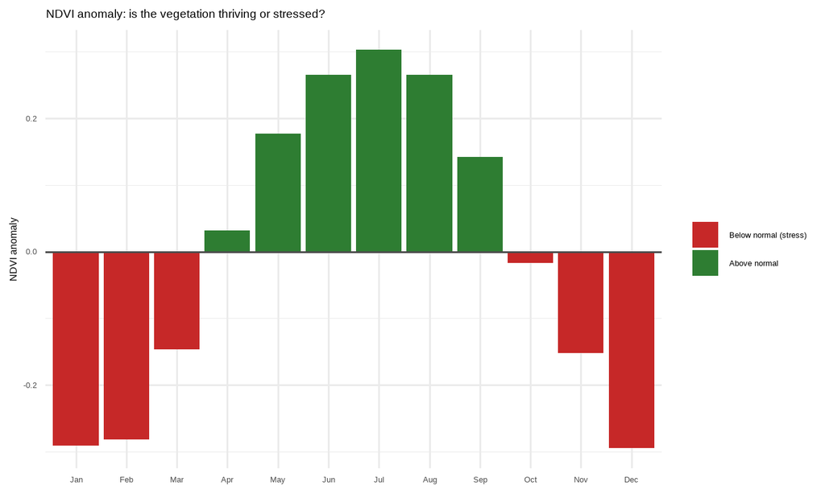

```r
ggplot(ndvi_data, aes(x = month, y = anomaly, fill = anomaly > 0)) +
  geom_col() +
  scale_fill_manual(
    values = c("TRUE" = "#2e7d32", "FALSE" = "#c62828"),
    labels = c("FALSE" = "Below normal (stress)", "TRUE" = "Above normal"),
    name = NULL
  ) +
  geom_hline(yintercept = 0, color = "grey30") +
  labs(
    title = "NDVI anomaly: is the vegetation thriving or stressed?",
    x = NULL, y = "NDVI anomaly"
  ) +
  theme_minimal(base_size = 12)
```

️**Civil connection:** NDVI anomalies feed into landslide risk (dead roots = weak slopes), irrigation planning, and urban heat island studies — exactly the mapping applications of Unit 4.

## 3.4 Why Engineered Features Matter (quick preview)

```r
# We build this dataset properly in Section 4; the message is simple:
cor(strength, age) # raw curing age: weaker, confusing signal
cor(strength, log_age) # engineered log(age): much clearer signal
```

[output not shown]

Concrete gains strength **fast early, slowly later** — a logarithmic pattern. Giving the model `log(age)` instead of raw `age` is like handing a student a neatly organised formula sheet instead of a pile of raw notes.

# Model Training and Validation

### What is it?

Training = the algorithm adjusts itself to fit the **training set**. Validation = checking it on the **unseen test set**. We use an **80/20 split**: 80% for learning, 20% for honest examination.

```r
set.seed(42)
n <- 120
concrete_ml <- data.frame(
  cement = runif(n, 200, 500), # kg/m3
  water  = runif(n, 140, 230), # litres/m3
  age    = sample(c(3, 7, 14, 28, 90), n, replace = TRUE) # days
)

# --- Feature engineering (Section 3 in action!) ---
concrete_ml$log_age <- log10(concrete_ml$age)

concrete_ml$strength <- round(5 + 0.08 * concrete_ml$cement - 0.10 * concrete_ml$water +
  12 * concrete_ml$log_age + rnorm(n, 0, 2.5), 1) # MPa

head(concrete_ml)
```

```
##     cement    water age   log_age strength
## 1 474.4418 172.1050   3 0.4771213     31.0
## 2 481.1226 176.9572  14 1.1461280     36.5
## 3 285.8419 191.6128  14 1.1461280     27.6
## 4 449.1343 193.0710  28 1.4471580     39.3
## 5 392.5237 204.7692  28 1.4471580     33.1
## 6 355.7288 175.5476  28 1.4471580     34.5
```

```r
c(
  "Correlation with raw age" = round(cor(concrete_ml$strength, concrete_ml$age), 3),
  "Correlation with log(age)" = round(cor(concrete_ml$strength, concrete_ml$log_age), 3)
)
```

```
##  Correlation with raw age Correlation with log(age)
##                     0.507                     0.589
```

The engineered `log_age` carries a clearer signal — the model will thank us.

```r
set.seed(101)
train_idx <- sample(seq_len(nrow(concrete_ml)), size = floor(0.8 * nrow(concrete_ml)))
train_set <- concrete_ml[train_idx, ]
test_set <- concrete_ml[-train_idx, ]

c(train_rows = nrow(train_set), test_rows = nrow(test_set))
```

```
## train_rows  test_rows
##         96         24
```

```r
strength_model <- lm(strength ~ cement + water + log_age, data = train_set)
summary(strength_model)
```

```
##
## Call:
## lm(formula = strength ~ cement + water + log_age, data = train_set)
##
## Residuals:
##     Min      1Q  Median      3Q     Max
## -6.5910 -1.6364 -0.1673  1.2929  5.2719
##
## Coefficients:
##              Estimate Std. Error t value Pr(>|t|)
## (Intercept)  6.307838   2.110941   2.988   0.0036 **
## cement       0.080363   0.002615  30.729   <2e-16 ***
## water       -0.107898   0.009368 -11.518   <2e-16 ***
## log_age     12.048630   0.475373  25.346   <2e-16 ***
## ---
## Signif. codes:  0 '***' 0.001 '**' 0.01 '*' 0.05 '.' 0.1 ' ' 1
##
## Residual standard error: 2.359 on 92 degrees of freedom
## Multiple R-squared:  0.9492, Adjusted R-squared:  0.9475
## F-statistic: 572.9 on 3 and 92 DF,  p-value: < 2.2e-16
```

**How to read the summary:** `Estimate` = the learned slope (e.g., each extra kg of cement adds ≈ 0.08 MPa). A tiny `Pr(>|t|)` (like < 0.001) means “this relationship is real, not luck”. We then ask the model to predict the **test set** it has never seen:

```r
test_pred <- predict(strength_model, newdata = test_set)
head(data.frame(actual = test_set$strength, predicted = round(test_pred, 1)))
```

```
##    actual predicted
## 1    31.0      31.6
## 5    33.1      33.2
## 12   37.2      36.2
## 13   28.6      29.4
## 21   44.2      41.4
## 27   31.2      32.5
```

# Evaluation Metrics for Regression (RMSE, MAE, R²)

### What is it?

Numbers that answer: **“How wrong are the predictions, and is the model actually useful?”**

| Metric | Formula | Plain English | Watch out for |
| --- | --- | --- | --- |
| **MAE** | $\frac{1}{n}\sum\lvert y-\hat{y}\rvert$ | “Average size of my mistake” | Treats all errors equally |
| **RMSE** | $\sqrt{\frac{1}{n}\sum (y-\hat{y})^2}$ | “Average mistake, but big errors punished extra” | Sensitive to outliers (can be good!) |
| **R²** | $1-\frac{SS_{res}}{SS_{tot}}$ | “Share of variation I explained” (0–1) | High R² alone can hide big errors |

**MAE vs RMSE — tiny example:** errors (4, 0): MAE = 2, RMSE = 2.83. Errors (2, 2): MAE = 2, RMSE = 2. Same MAE, but RMSE is worse for the scattered model! RMSE **hates big blunders** — perfect for concrete, where a badly wrong strength guess is dangerous.

```r
# Reusable metric functions (we will use them again later!)
mae <- function(actual, predicted) mean(abs(actual - predicted))
rmse <- function(actual, predicted) sqrt(mean((actual - predicted)^2))
r_squared <- function(actual, predicted) {
  1 - sum((actual - predicted)^2) / sum((actual - mean(actual))^2)
}

knitr::kable(data.frame(
  Metric = c("MAE (MPa)", "RMSE (MPa)", "R-squared"),
  Value = c(
    round(mae(test_set$strength, test_pred), 2),
    round(rmse(test_set$strength, test_pred), 2),
    round(r_squared(test_set$strength, test_pred), 3)
  )
), caption = "Our model on the unseen test set")
```

Our model on the unseen test set

| Metric | Value |
| --- | --- |
| MAE (MPa) | 1.890 |
| RMSE (MPa) | 2.320 |
| R-squared | 0.915 |

**Always compare with a lazy baseline** — “guess the average strength for everything”:

```r
baseline_pred <- rep(mean(train_set$strength), nrow(test_set))
c(
  "RMSE of lazy baseline" = round(rmse(test_set$strength, baseline_pred), 2),
  "RMSE of our model" = round(rmse(test_set$strength, test_pred), 2)
)
```

```
## RMSE of lazy baseline     RMSE of our model
##                  8.40                  2.32
```

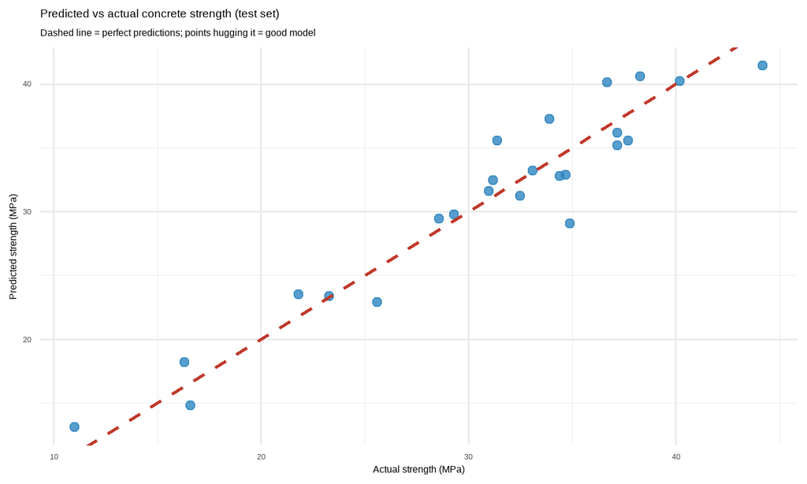

```r
ggplot(
  data.frame(actual = test_set$strength, predicted = test_pred),
  aes(x = actual, y = predicted)
) +
  geom_point(color = "#2e86c1", size = 2.5, alpha = 0.8) +
  geom_abline(
    slope = 1, intercept = 0, linetype = "dashed",
    color = "#c0392b", linewidth = 1
  ) +
  labs(
    title = "Predicted vs actual concrete strength (test set)",
    subtitle = "Dashed line = perfect predictions; points hugging it = good model",
    x = "Actual strength (MPa)", y = "Predicted strength (MPa)"
  ) +
  theme_minimal(base_size = 12)
```

# Evaluation Metrics for Classification (Accuracy, Precision, Recall, F1, ROC)

### What is it?

Classification predicts a **category** — e.g., *“Will this catchment flood this monsoon: Yes or No?”* We judge it with a **confusion matrix** and its children: Accuracy, Precision, Recall, F1, and the ROC curve.

## 6.1 The Flood-Warning Dataset (simulated so results reproduce)

```r
set.seed(7)
n <- 200
rain <- runif(n, 10, 120) # rainfall, mm
p_flood_true <- plogis((rain - 70) / 15) # true flood probability
actual <- factor(ifelse(runif(n) < p_flood_true, "Flood", "No Flood"),
  levels = c("Flood", "No Flood")
)

p_model <- plogis((rain - 72) / 14 + rnorm(n, 0, 0.35)) # our model's opinion
predicted <- factor(ifelse(p_model >= 0.5, "Flood", "No Flood"),
  levels = c("Flood", "No Flood")
)
```

## 6.2 The Confusion Matrix — 4 Verbs of Judgement

|  | **Actually Flood** | **Actually No Flood** |
| --- | --- | --- |
| **We warned (Flood)** | **TP** — correct siren! | **FP** — false alarm (costly evacuation) |
| **We stayed quiet** | **FN** — MISSED flood (dangerous!) | **TN** — correct silence |

```r
cm <- table(Predicted = predicted, Actual = actual)
knitr::kable(cm, caption = "Confusion matrix for the flood-warning model")
```

Confusion matrix for the flood-warning model

|  | Flood | No Flood |
| --- | --- | --- |
| Flood | 74 | 19 |
| No Flood | 15 | 92 |

## 6.3 The Four Key Metrics

$$\text{Accuracy} =
\frac{TP+TN}{\text{All}} \quad \text{Precision} = \frac{TP}{TP+FP} \quad
\text{Recall} = \frac{TP}{TP+FN} \quad F1 = \frac{2 \cdot P \cdot
R}{P+R}$$

️**Civil meaning:** **Precision** = “When the siren rang, how often was it real?” (false alarms make people ignore warnings — the boy who cried wolf). **Recall** = “Of all real floods, how many did we catch?” (missing a flood endangers lives). A flood system must have **high recall** even if precision suffers slightly.

```r
TP <- cm["Flood", "Flood"]
FP <- cm["Flood", "No Flood"]
FN <- cm["No Flood", "Flood"]
TN <- cm["No Flood", "No Flood"]

P <- TP / (TP + FP)
R <- TP / (TP + FN)
knitr::kable(data.frame(
  Metric = c("Accuracy", "Precision", "Recall (Sensitivity)", "F1 Score"),
  Formula = c("(TP+TN)/All", "TP/(TP+FP)", "TP/(TP+FN)", "2PR/(P+R)"),
  Value = round(c((TP + TN) / sum(cm), P, R, 2 * P * R / (P + R)), 3)
))
```

| Metric | Formula | Value |
| --- | --- | --- |
| Accuracy | (TP+TN)/All | 0.830 |
| Precision | TP/(TP+FP) | 0.796 |
| Recall (Sensitivity) | TP/(TP+FN) | 0.831 |
| F1 Score | 2PR/(P+R) | 0.813 |

️**The accuracy trap:** if floods happen only 1% of the time, a lazy model that ALWAYS says “No Flood” scores 99% accuracy and 0% recall — while missing every single flood. For rare, dangerous events, trust Recall/F1, never accuracy alone.

## 6.4 The Threshold Slider — Same Model, Different Personalities

The 0.5 cut-off was our choice. Move it and watch the trade-off:

```r
thr_table <- do.call(rbind, lapply(c(0.30, 0.50, 0.70), function(t) {
  pred_t <- factor(ifelse(p_model >= t, "Flood", "No Flood"),
    levels = c("Flood", "No Flood")
  )
  cm_t <- table(pred_t, actual)
  TP <- cm_t["Flood", "Flood"]
  FP <- cm_t["Flood", "No Flood"]
  FN <- cm_t["No Flood", "Flood"]
  TN <- cm_t["No Flood", "No Flood"]
  data.frame(
    Threshold = t,
    Accuracy = round((TP + TN) / sum(cm_t), 3),
    Precision = round(TP / (TP + FP), 3),
    Recall = round(TP / (TP + FN), 3)
  )
}))
knitr::kable(thr_table,
  row.names = FALSE,
  caption = "Lower threshold = more warnings = higher recall, more false alarms"
)
```

Lower threshold = more warnings = higher recall, more false alarms

| Threshold | Accuracy | Precision | Recall |
| --- | --- | --- | --- |
| 0.3 | 0.775 | 0.690 | 0.899 |
| 0.5 | 0.830 | 0.796 | 0.831 |
| 0.7 | 0.840 | 0.890 | 0.730 |

## 6.5 The ROC Curve — Judging Across ALL Thresholds at Once

The ROC curve plots **Recall (TPR)** against **False Alarm Rate (FPR)** for every possible threshold. The **Area Under the Curve (AUC)** summarises it: 1.0 = perfect, 0.5 = coin-flip guessing.

```r
thresholds <- seq(0, 1, by = 0.01)
tpr <- sapply(thresholds, function(t) sum(p_model >= t & actual == "Flood") / sum(actual == "Flood"))
fpr <- sapply(thresholds, function(t) sum(p_model >= t & actual == "No Flood") / sum(actual == "No Flood"))

roc_df <- data.frame(fpr, tpr)[order(fpr, tpr), ]
auc <- sum(diff(roc_df$fpr) * (head(roc_df$tpr, -1) + tail(roc_df$tpr, -1)) / 2) # trapezoid rule
c(AUC = round(auc, 3))
```

```
##   AUC
## 0.911
```

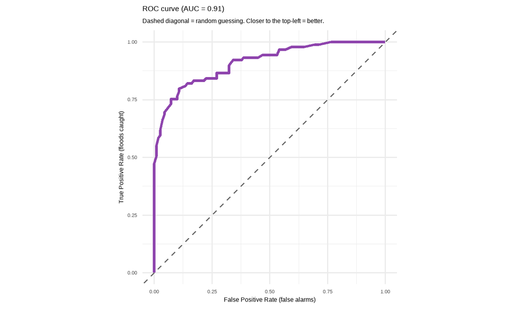

```r
ggplot(roc_df, aes(x = fpr, y = tpr)) +
  geom_line(color = "#8e44ad", linewidth = 1.3) +
  geom_abline(slope = 1, intercept = 0, linetype = "dashed", color = "grey40") +
  coord_equal(xlim = c(0, 1), ylim = c(0, 1)) +
  labs(
    title = paste0("ROC curve (AUC = ", round(auc, 2), ")"),
    subtitle = "Dashed diagonal = random guessing. Closer to the top-left = better.",
    x = "False Positive Rate (false alarms)",
    y = "True Positive Rate (floods caught)"
  ) +
  theme_minimal(base_size = 12)
```

**Note:** we built the ROC by hand so you understand it. In practice, the `pROC` or `ROCR` packages do this in one line — and Unit 4’s logistic regression will produce these probabilities directly.

# Statistical Challenges — Overfitting, Underfitting & the Bias–Variance Tradeoff

### What is it?

The Goldilocks problem of ML: a model can be **too simple**, **too complicated**, or **just right**.

**Student analogy:** - **Underfitting** = a student who didn’t study at all — fails the mock exam AND the final (poor everywhere). - **Overfitting** = a student who memorised the mock exam answers word-for-word — aces the mock, fails the final because questions changed. - **Good fit** = a student who understood the concepts — good in both.

## 7.1 Experiment: Seasonal Groundwater Level

Groundwater follows a seasonal wave. We fit polynomials of degree 1 (a straight line), 4 (smooth curve), and 15 (a noodle) and compare **training vs test RMSE**:

```r
set.seed(100)
n_fit <- 60
x_all <- runif(n_fit, 0, 12) # month of year
y_all <- 8 + 3 * sin(2 * pi * x_all / 12) + rnorm(n_fit, 0, 0.8) # water table (m)

split_idx <- sample(seq_len(n_fit), size = 0.7 * n_fit)
d_train <- data.frame(x = x_all[split_idx], y = y_all[split_idx])
d_test <- data.frame(x = x_all[-split_idx], y = y_all[-split_idx])
```

```r
degrees <- c(1, 4, 15)
results <- do.call(rbind, lapply(degrees, function(d) {
  m <- lm(y ~ poly(x, d), data = d_train)
  data.frame(
    Degree = d,
    Train_RMSE = round(rmse(d_train$y, predict(m)), 3),
    Test_RMSE = round(rmse(d_test$y, predict(m, newdata = d_test)), 3)
  )
}))
results$Verdict <- c("Too simple → UNDERFITS", "Good balance ", "Memorises noise → OVERFITS")
results
```

```
##   Degree Train_RMSE Test_RMSE                    Verdict
## 1      1      1.656     0.965     Too simple → UNDERFITS
## 2      4      0.896     0.929              Good balance
## 3     15      0.755     0.960 Memorises noise → OVERFITS
```

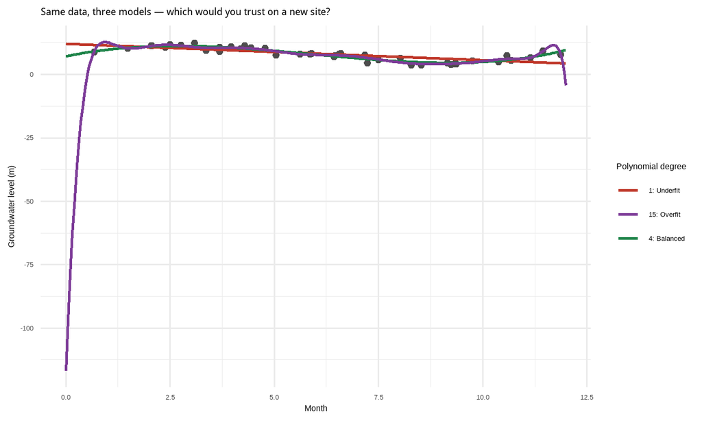

```r
grid <- data.frame(x = seq(0, 12, length.out = 300))
grid$deg1 <- predict(lm(y ~ poly(x, 1), d_train), newdata = grid)
grid$deg4 <- predict(lm(y ~ poly(x, 4), d_train), newdata = grid)
grid$deg15 <- predict(lm(y ~ poly(x, 15), d_train), newdata = grid)

ggplot() +
  geom_point(data = d_train, aes(x, y), color = "grey30", size = 2) +
  geom_line(data = grid, aes(x, deg1, color = "1: Underfit"), linewidth = 1) +
  geom_line(data = grid, aes(x, deg4, color = "4: Balanced"), linewidth = 1) +
  geom_line(data = grid, aes(x, deg15, color = "15: Overfit"), linewidth = 1) +
  scale_color_manual(values = c(
    "1: Underfit" = "#c0392b",
    "4: Balanced" = "#1e8449",
    "15: Overfit" = "#7d3c98"
  ), name = "Polynomial degree") +
  labs(
    title = "Same data, three models — which would you trust on a new site?",
    x = "Month", y = "Groundwater level (m)"
  ) +
  theme_minimal(base_size = 12)
```

## 7.2 The Bias–Variance Tradeoff

Total expected error decomposes as:

$$\text{Total Error} = \text{Bias}^2 +
\text{Variance} + \text{Irreducible Noise}$$

Think of a **dartboard**: **bias** = systematically aiming wrong (darts clustered away from the bullseye); **variance** = shaky hands (darts scattered everywhere).

| Model | Bias | Variance | Behaviour |
| --- | --- | --- | --- |
| Degree 1 (straight line on a wave) | High | Low | Underfits |
| Degree 4 (smooth curve) | Medium | Medium | **Just right** |
| Degree 15 (noodle) | Low | High | Overfits |

**How engineers fight it:** more data, simpler models, fewer features, regularisation — and **cross-validation** to *find* the sweet spot, which brings us to…

# Cross-Validation Techniques — Many Mock Exams, Not One

### What is it?

A single train/test split can be lucky or unlucky. **K-fold cross-validation** rotates the exam: split training data into k folds, train on k−1, test on the remaining fold, repeat k times, and average. **Every data point gets examined exactly once.**

```r
fold_demo <- matrix(" Train", nrow = 5, ncol = 5)
diag(fold_demo) <- " TEST"
knitr::kable(fold_demo,
  col.names = paste0("Fold ", 1:5),
  caption = "5-fold CV: in each round one red block is the test set"
)
```

5-fold CV: in each round one red block is the test set

| Fold 1 | Fold 2 | Fold 3 | Fold 4 | Fold 5 |
| --- | --- | --- | --- | --- |
| TEST | Train | Train | Train | Train |
| Train | TEST | Train | Train | Train |
| Train | Train | TEST | Train | Train |
| Train | Train | Train | TEST | Train |
| Train | Train | Train | Train | TEST |

```r
set.seed(5)
k <- 5
folds <- sample(rep(1:k, length.out = nrow(train_set)))

cv_results <- data.frame(fold = 1:k, rmse_with_log_age = NA, rmse_without_log_age = NA)

for (i in 1:k) {
  cv_train <- train_set[folds != i, ]
  cv_test <- train_set[folds == i, ]

  m_full <- lm(strength ~ cement + water + log_age, data = cv_train)
  m_simple <- lm(strength ~ cement + water, data = cv_train)

  cv_results$rmse_with_log_age[i] <- rmse(cv_test$strength, predict(m_full, newdata = cv_test))
  cv_results$rmse_without_log_age[i] <- rmse(cv_test$strength, predict(m_simple, newdata = cv_test))
}
cv_results
```

```
##   fold rmse_with_log_age rmse_without_log_age
## 1    1          2.465418             5.831858
## 2    2          2.681817             6.701626
## 3    3          2.485740             7.733147
## 4    4          2.509193             6.283093
## 5    5          1.657015             6.748487
```

```r
knitr::kable(data.frame(
  Model = c("With log_age feature", "Without log_age"),
  Mean_CV_RMSE = round(colMeans(cv_results[, 2:3]), 2),
  SD_CV_RMSE = round(apply(cv_results[, 2:3], 2, sd), 2)
), caption = "Average of 5 exams is far more trustworthy than one exam")
```

Average of 5 exams is far more trustworthy than one exam

|  | Model | Mean_CV_RMSE | SD_CV_RMSE |
| --- | --- | --- | --- |
| rmse_with_log_age | With log_age feature | 2.36 | 0.40 |
| rmse_without_log_age | Without log_age | 6.66 | 0.71 |

️**Civil reading:** CV confirms the `log_age` feature genuinely helps (lower mean RMSE) — this is the honest way to justify design decisions, just like a load test averages several specimens instead of trusting one cube.

**Variants you should recognise:** - **LOOCV** (Leave-One-Out): k = n — every single row takes a turn as the test set (accurate but slow). - **Repeated k-fold**: repeat the whole procedure several times for extra stability. - **Golden rule:** run CV *inside the training data only* to choose models; touch the held-out test set **once**, at the very end.

# One-Page Summary (Pin This!)

| Concept | One-line takeaway |
| --- | --- |
| ML workflow | Ask → Collect → Prepare → Split → Train → Evaluate → Deploy |
| Cleaning | No NA, no duplicates, no impossible values before modelling |
| Min-Max / Z-score | Fair comparison when columns have different units/spreads |
| One-hot encoding | Words → 1/0 columns (for categories with no order) |
| Feature engineering | Rainfall intensity, runoff C, NDVI anomaly, log(age) = raw data made meaningful |
| Train/test split | Mock exam vs final exam — never leak |
| MAE / RMSE / R² | Avg error / avg error punishing blunders / % of variation explained |
| Precision / Recall | Alarm accuracy / floods caught — rare dangers need recall |
| F1 / ROC-AUC | Balance of P&R / quality across all thresholds |
| Overfitting | Memorises noise; train error ↓, test error ↑ |
| Bias–Variance | Too simple vs too wiggly — seek the sweet spot |
| K-fold CV | Average of k exams; the honest model selector |

# Mini Glossary

- **Feature** — an input column the model learns from (cement, rainfall intensity).
- **Label / Target** — what we predict (strength, Flood/No Flood).
- **Training set** — data the model learns from. **Test set** — data for honest grading.
- **Imputation** — filling missing values (e.g., with the median).
- **Normalization / Standardization** — rescaling features to comparable ranges.
- **One-hot encoding** — one 1/0 column per category.
- **Confusion matrix** — 2×2 table of TP, FP, FN, TN.
- **ROC curve / AUC** — performance across all thresholds / area under it.
- **Bias** — systematic error from a too-simple model. **Variance** — instability of a too-complex model.
- **Cross-validation** — rotating train/test rounds averaged for reliability.

# ️ Exit Ticket — Test Yourself!

**Q1.** Normalise cement = 350 kg/m³ given min = 200 and max = 500.

**Q2.** A storm drops 48 mm in 1.5 hours. Compute the rainfall intensity.

**Q3.** Using the Rational Method, find Q for C = 0.75, i = 40 mm/hr, A = 10 ha.

**Q4.** A flood model gives TP = 40, FP = 10, FN = 20, TN = 130. Find Accuracy, Precision, Recall, and F1.

**Q5.** Why can 99% accuracy be a disaster for flood prediction?

**Click for answers**

**A1.** $x' = (350-200)/(500-200) = 0.5$

**A2.** $I = 48/1.5 = 32$ mm/hr.

**A4.** Accuracy = 170/200 = **0.85**; Precision = 40/50 = **0.80**; Recall = 40/60 ≈ **0.667**; F1 = 2(0.8)(0.667)/(0.8+0.667) ≈ **0.727**.

**A5.** If floods are 1% of cases, “always say No Flood” scores 99% accuracy but **Recall = 0** — it misses every real flood, which is exactly the dangerous failure mode. Use Recall/F1 for rare, hazardous events.

# Where This Comes From (Further Reading)

1. James, G., Witten, D., Hastie, T., & Tibshirani, R. (2021). *An Introduction to Statistical Learning* (2nd ed.) — Chapters 2 & 5 (resampling/CV). Free at statlearning.com.
2. Wickham, C., Çetinkaya-Rundel, M., & Grolemund, G. (2023). *R for Data Science* (2nd ed.) — data cleaning & transformation. Free at r4ds.hadley.nz.
3. Musoko, C. (2024). *Explainable Machine Learning for Geospatial Data Analysis* — feature engineering for spatial data.
4. Course notes 24CV201T, Units 3 & 4 (next unit: real algorithms — logistic regression, trees, KNN — evaluated with exactly these metrics!).